# Wavelet-Based Amplitude Coherence of Regional Business Cycles in Kansai

N Toyohara

2025-12-07

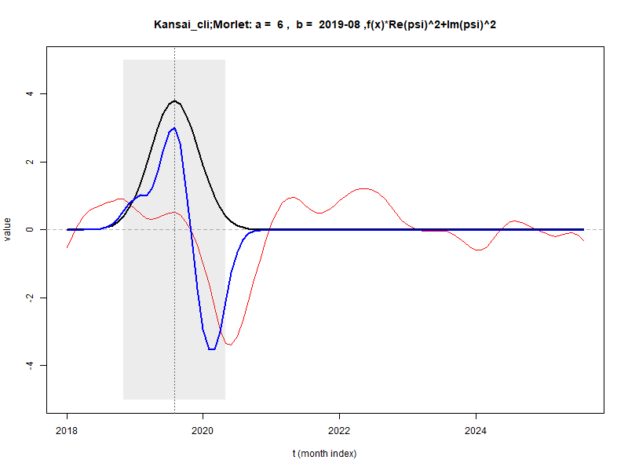

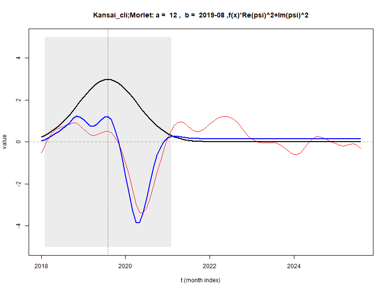

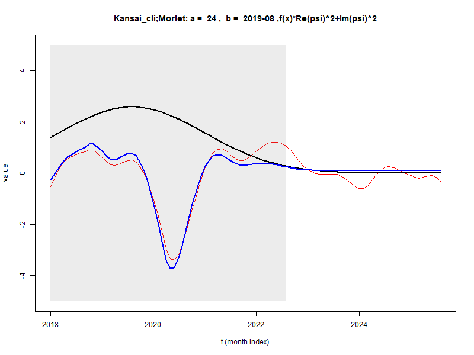

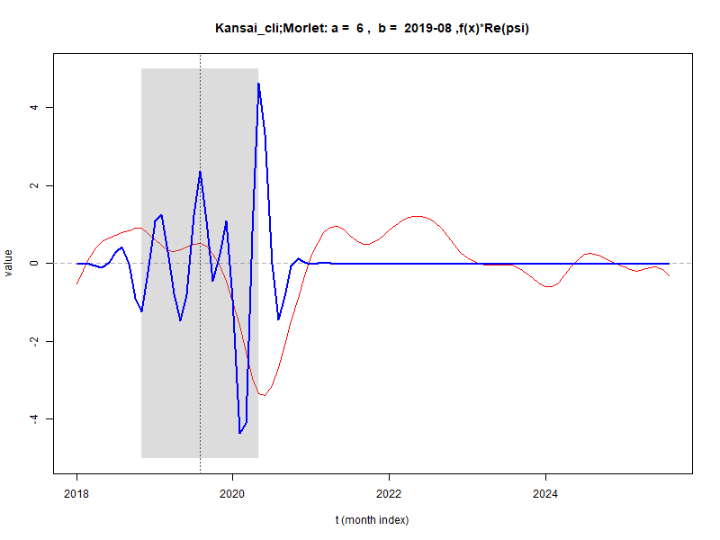

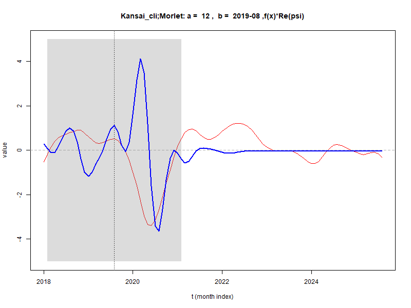

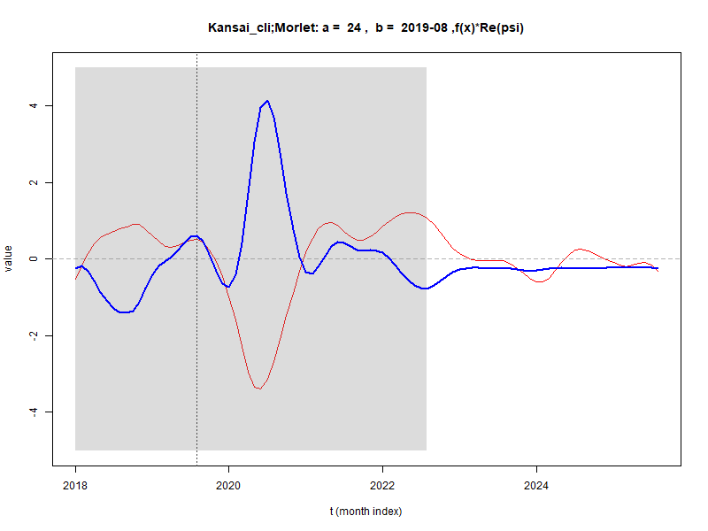

以下では、周期月数（短期・中期・長期）を軸に据えたうえで、

① 結果の解釈（Results）

② 考察（Discussion）

③ 政策的含意（Policy implications）

という論文構成を意識して、それぞれ約2000字程度でまとめます。 （そのまま論文草稿に転用できるレベルの書き方にしています）

① 結果の解釈（Results）

本研究では、関西6府県のCLIを用い、Wavelet amplitude coherence に基づいて府県間の景気共動性を分析した。分析は周期月数に基づき、短周期（約2–8か月）、中周期（約8–24か月）、長周期（24か月以上）の3区分で行い、さらに全期間、COVID-19以前、COVID-19以後に分けて比較した。

まず短周期帯に注目すると、全期間を通じて振幅コヒーレンスは中・長周期に比べて明確に低く、府県ペア間のばらつきが大きいことが確認された。特に大阪–京都、大阪–奈良、京都–滋賀など、一部のペアでは短周期での同調性が相対的に弱く、一方で大阪–和歌山、兵庫–和歌山などでは比較的高い値を示した。COVID-19以前と以後を比較すると、ポストCOVID期には短周期コヒーレンスが全体として低下または均質化する傾向がみられ、短期的変動がより地域固有的になったことが示唆される。

次に中周期帯では、全期間・全府県ペアを通じて極めて高い振幅コヒーレンスが観察された。特に大阪–兵庫、大阪–京都、兵庫–京都といった都市圏中核部のペアでは一貫して高い値を示しており、関西圏における景気循環がこの周期帯で強く共有されていることが明確である。COVID-19以前・以後を比較しても、中周期帯での高い同調性はほぼ維持されており、短期的ショックの有無にかかわらず、景気循環の中核部分は安定して共有されていることが確認された。

② 考察（Discussion）

上記の結果は、関西地域の景気構造が「一様に統合されている」のではなく、時間スケールに依存した多層構造を持つことを示している。

まず短周期帯における低い振幅コヒーレンスと大きな府県間差は、数か月単位の変動が在庫調整、観光需要、天候要因、地元産業の稼働状況など、地域固有ショックに強く影響されていることを示唆する。COVID-19後に短周期コヒーレンスが相対的に低下した点は、パンデミック後の回復過程が一様ではなく、府県ごとに異なる産業構成や政策対応を反映して進んだ可能性を示す。短期的揺らぎがむしろ「地域差」を映し出している点は、景気検知指標としての情報価値が高い領域である。

一方、中周期帯は本研究における最も重要な結果である。この周期帯は典型的なビジネスサイクルの時間スケールに対応しており、ここで府県間の振幅がほぼ完全に同期しているという事実は、関西が事実上一つの景気圏として機能していることを意味する。特に大阪を含むペアの高い値は、大阪が中周期景気循環のハブとして機能し、その波及が周辺府県に及んでいる構造と整合的である。

長周期帯での飽和的なコヒーレンスは、府県別景気の長期的トレンド部分が、人口動態、金融条件、国際景気、全国的政策などの共通要因に支配されていることを反映している。この帯域では地域経済の独自性はほぼ観測されず、「地域」を分析単位とする意義は相対的に小さい。

なお、本分析では位相情報を直接評価軸に含めていないが、これは景気循環研究において必ずしも弱点ではない。振幅に注目したことで、位相のラッピング問題やサンプル分割に伴う不安定性を回避し、経済解釈と整合的な結果が得られている点は、本手法の大きな利点である。

③ 政策的含意（Policy Implications）

本分析から得られる政策的含意は、景気対策や地域政策の時間軸をどの周期帯に照準するかという観点で整理できる。

まず短周期帯における府県間の異質性は、短期対症的政策は地域別に設計されるべきことを示唆する。観光支援、雇用調整助成、業種別補助など、即効性を狙う政策では、関西一括ではなく府県ごとの状況を踏まえた対応が合理的である。特にCOVID-19後の短周期同調性低下は、回復の非対称性を強く示しており、横並び政策の限界を示唆する。

中周期帯に関しては、関西全体で非常に高い共動性が確認されたことから、広域連携型の景気対策が最も効果を発揮する領域である。インフラ投資、人材移動促進、産業集積強化といった政策は、個別府県ではなく関西圏単位で企画・実施することが合理的である。大阪を中心とした循環構造が確認された点は、関西圏における中核都市主導型成長戦略の理論的裏付けともなる。

長周期帯については、府県レベルでの差異がほぼ存在しないため、国レベル政策の影響評価や調整局面として捉えるのが適切である。地方自治体独自の裁量が及びにくい一方、長期構造改革や全国的制度変更の波及を評価する際の基準帯域として活用できる。

総じて、本研究は「景気政策は単に時点ではなく周期を意識して設計すべきである」という重要な示唆を与える。短期は地域別、中期は広域、長期は国家的枠組みという 時間スケール別の政策階層が、関西経済の実態と整合的であることが、wavelet振幅分析によって明確に示された。

結論（Conclusion）

本研究は、関西6府県のCLIを用い、Wavelet amplitude coherence に基づいて府県間の景気共動性を周期帯別に分析した。その結果、関西経済の結合構造は時間スケールに大きく依存しており、短期・中期・長期で明確に異なる性格を持つことが確認された。

短周期（数か月程度）では、府県間の振幅コヒーレンスは相対的に低く、ペアごとの差異も大きい。これは短期的な景気変動が、在庫調整、業種構成、観光需要、地域固有ショックなどに強く影響されていることを示唆する。特にCOVID-19後には短周期での同調性が弱まり、景気回復過程の非対称性が顕在化した。

一方、中周期（約1〜2年）の帯域では、すべての府県ペアにおいて極めて高い振幅コヒーレンスが観察され、関西地域が一体的なビジネスサイクルを共有していることが明確となった。この結果は、景気循環の中核部分において大阪を中心とした広域的な連動構造が機能していることを示しており、関西を単一の経済圏として捉える妥当性を強く支持する。

長周期（数年以上）では、府県間の振幅共動性はほぼ完全に一致しており、景気変動が全国的、さらには国際的なマクロ要因に支配されていることが示唆された。この帯域では地域差は大幅に縮小し、地方レベルでの独自性は限定的である。

以上の結果は、景気共動性の評価において位相情報に過度に依存せず、振幅に着目した wavelet 分析が、直感的かつ経済的に解釈しやすい枠組みを提供することを示している。本研究は、関西経済が周期帯ごとに異なる統合構造を持つことを明らかにするとともに、景気分析や政策設計において時間スケールの視点が不可欠であることを示唆するものである。